# mvgam case study 1: model comparison and data assimilation

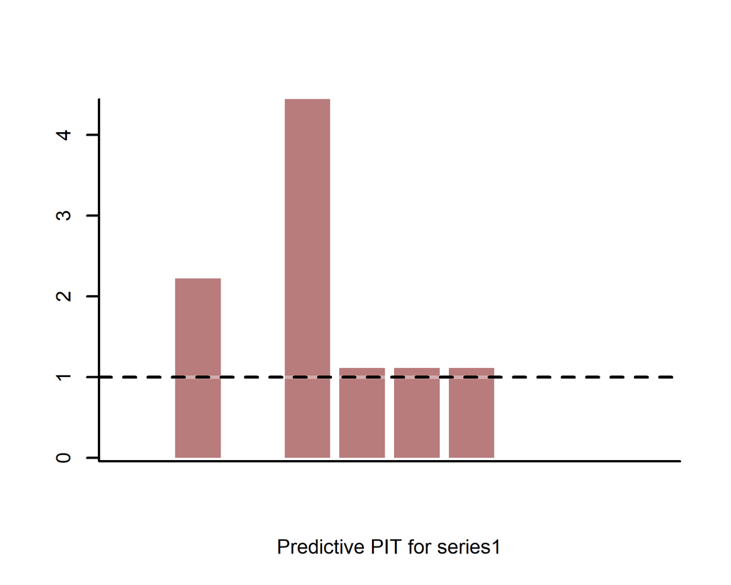

```r
ppc(m_mvgam, series = 1, type = 'pit', newdata = data_test)
```

There are some problems with the way this model is generating future predictions, so we would need to perform a more rigorous and principled model development strategy to improve our model’s predictive abilities. But there are two other utilities available in `mvgam` that are worth highlighting. The first is model comparison. Benchmarking against “null” models is a very important part of evaluating a proposed forecast model. After all, if our complex dynamic model can’t generate better predictions then a random walk or mean forecast, is it really telling us anything new about the data-generating process? Here we examine the model comparison utilities in `mvgam`. Here we illustrate how this can be done in `mvgam` by fitting a basic random walk model with a Negative Binomial observation process. No smooth terms are included here, the observation model simply has an intercept term.

```r
m_mvgam2 <- mvgam(y ~ 1,
                 data = data_train,
                 newdata = data_test,
                 family = 'nb',
                 trend_model = 'RW',
                 use_stan = TRUE,
                 chains = 4)
```

[output not shown]

Look at this model’s proposed forecast, which incidentally isn’t too bad compared to the original `AR3` model

```
## Out of sample DRPS:
```

```
## [1] 2182.206
```

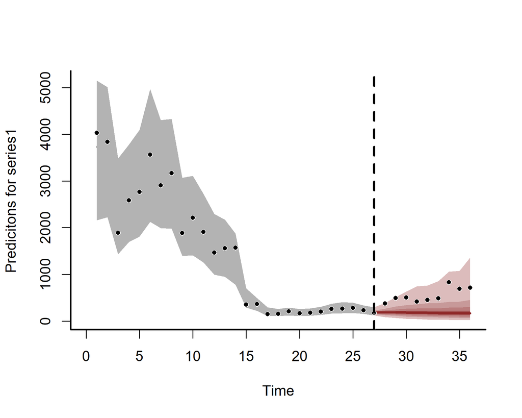

```r
plot(m_mvgam2, series = 1, type = 'forecast', newdata = data_test)
```

```
## Out of sample DRPS:
```

```
## [1] 2067.32
```

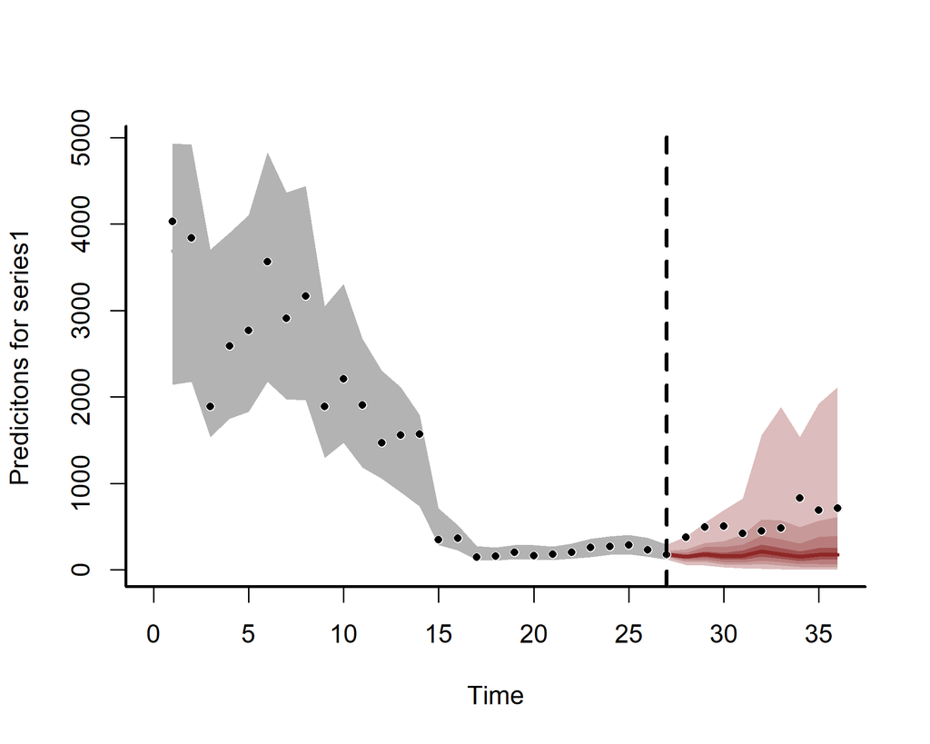

```r
plot(m_mvgam, series = 1, type = 'forecast', newdata = data_test)
```

Now we will showcase how different dynamic models can be compared using rolling probabilistic forecast evaluation, which is especially useful if we don’t already have out of sample observations for comparing forecasts. This function sets up a sequence of evaluation timepoints along a rolling window within the training data to evaluate ‘out-of-sample’ forecasts. The trends are rolled forward a total of `fc_horizon` timesteps according to their estimated state space dynamics to generate an ‘out-of-sample’ forecast that is evaluated against the true observations in the `horizon` window. We are therefore simulating a situation where the model’s parameters had already been estimated but we have only observed data up to the evaluation timepoint and would like to generate forecasts that consider the possible future paths for the latent trends and the true observed values for any other covariates in the `horizon` window. Evaluation involves calculating the Discrete Rank Probability Score and a binary indicator for whether or not the true value lies within the forecast’s 90% prediction interval. For this test we compare the two models on the exact same sequence of `30` evaluation points using `horizon = 6`

```r
compare_mvgams(model1 = m_mvgam, model2 = m_mvgam2, fc_horizon = 6,
               n_evaluations = 30, n_cores = 3)
```

```
## RPS summaries per model (lower is better)
##             Min.   1st Qu.    Median      Mean   3rd Qu.      Max.
## Model 1 1385.455  2169.467  3665.923  3595.176  4764.177  6052.847
## Model 2 9072.482 10078.607 11827.994 11760.198 13064.054 14861.168
##
## 90% interval coverages per model (closer to 0.9 is better)
## Model 1 0.8611111
## Model 2 0.4722222
```

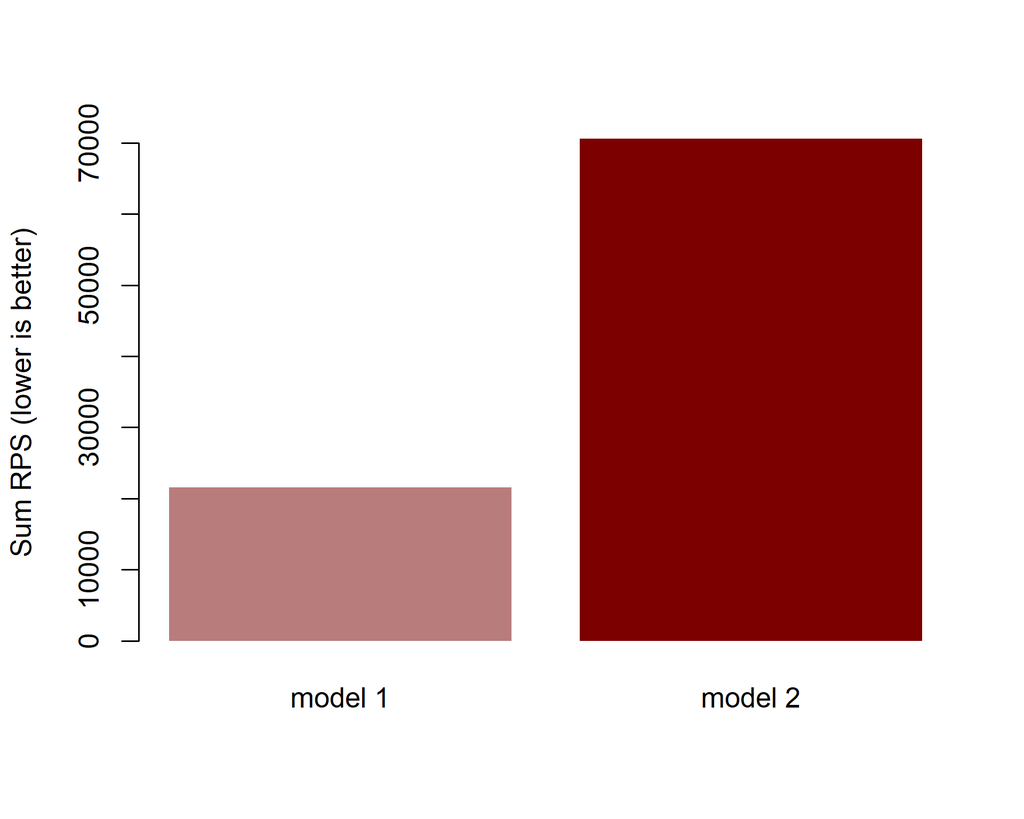

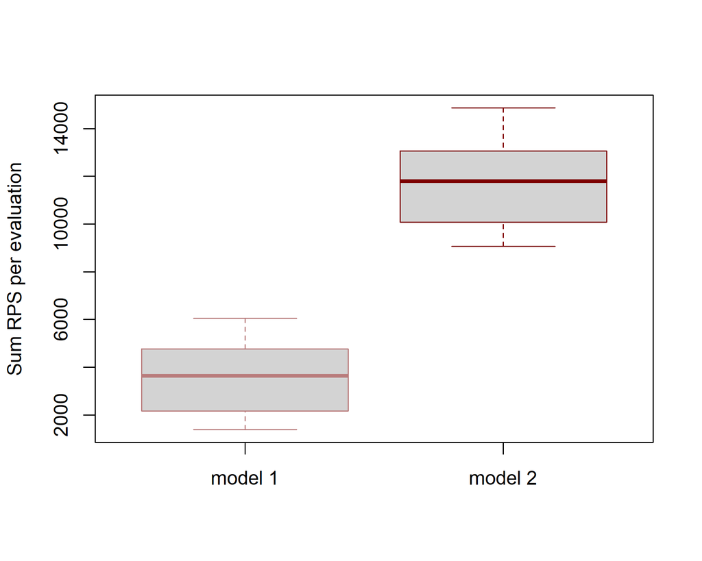

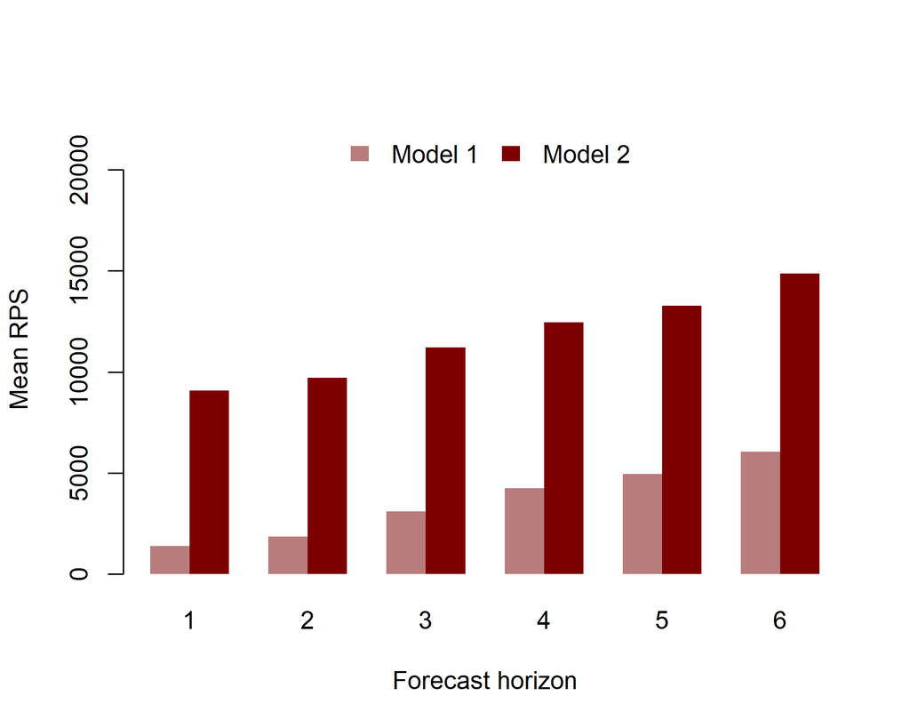

The series of plots generated by `compare_mvgams` clearly show that the first dynamic model generates better predictions. In each plot, DRPS for the forecast `horizon` is lower for the first model than for the second model. This kind of evaluation is often more appropriate for forecast models than complexity-penalising fit metrics such as [`AIC` or `BIC`](https://www.sciencedirect.com/science/article/pii/S0169207020301096). Now we proceed by exploring how forecast distributions from an `mvgam` object can be automatically updated in light of new incoming observations. This works by generating a set of “particles” that each captures a unique proposal about the current state of the system (in this case, the current estimate of the latent trend component). The next observation in `data_assim` is assimilated and particles are weighted by how well their proposal (i.e. their proposed forecast, prior to seeing the new data) matched the new observations. For univariate models such as the ones we’ve fitted so far, this weight is represented by the proposal’s Negative Binomial log-likelihood. For multivariate models, a multivariate composite likelihood is used for weights. Once weights are calculated, we use importance sampling to update the model’s forecast distribution for the remaining forecast horizon. Begin by initiating a set of `20000` particles by assimilating the next observation in `data_test` and storing the particles in the default location (in a directory called `particles` within the working directory)

```r
pfilter_mvgam_init(object = m_mvgam, n_particles = 20000,
                   n_cores = 3, data_assim = model_dat[28,])
```

```
## Saving particles to pfilter/particles.rda
##  ESS = 1827.227
```

Now we are ready to run the particle filter. This function will assimilate the next two out of sample observations in `data_test` and update the forecast after each assimilation step. This works in an iterative fashion by calculating each particle’s weight, then using a kernel smoothing algorithm to “pull” low weight particles toward the high-likelihood space before assimilating the next observation. The strength of the kernel smoother is controlled by `kernel_lambda`, which in our experience works well when left to the default of `1`. If the Effective Sample Size of particles drops too low, suggesting we are putting most of our belief in a very small set of particles, an automatic resampling step is triggered to increase particle diversity and reduce the chance that our forecast intervals become too narrow and incapable of adapting to changing conditions

```r
pfilter_mvgam_online(data_assim = model_dat[29:30, ], n_cores = 3,
                     kernel_lambda = 1, use_resampling = TRUE)
```

```
## Assimilating the next 2 observations
##
## Effective sample size is 1838.48 ...
##
## Resampling particles ...
## Smoothing particles ...
##
## Effective sample size is 5540.096 ...
##
## Resampling particles ...
## Smoothing particles ...
##
## Last assimilation time was 30
##
## Saving particles to pfilter/particles.rda
##  ESS = 20000
```

Once assimilation is complete, generate the updated forecast from the particles using the covariate information in remaining `data_test` observations. This function is designed to hopefully make it simpler to assimilate observations, as all that needs to be provided once the particles are initiated as a dataframe of test data in exactly the same format as the data that were used to train the initial model. If no new observations are found (observations are arranged by `time` so the consistent indexing of these two variables is very important!) then the function returns a `NULL` and the particles remain where they are in state space.

```r
pfilter_fc <- pfilter_mvgam_fc(file_path = "pfilter",
                       n_cores = 3, newdata = model_dat[31:36,],
                       return_forecasts = TRUE,
                       ylim = c(0, 5100))
```

Compare the updated forecast to the original forecast to see how it has changed in light of the most recent observations. As with the `plot_mvgam_smooth()` function, the `plot_mvgam_fc()` function has more flexibility for plotting posterior predictive distributions than the generic `plot.mvgam() S3` function

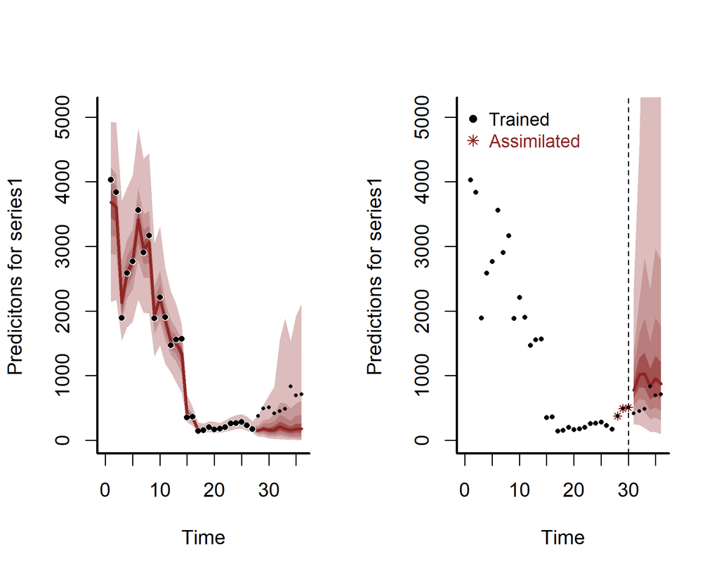

```r
layout(matrix(1:2,nrow=1,ncol=2))
plot_mvgam_fc(m_mvgam,
     ylim = c(0, 5100))
points(model_dat$y, pch = 16, cex = 0.4)
pfilter_fc$fc_plots$series1()
points(model_dat$y, pch = 16, cex = 0.4)
```

Here it is apparent that the distribution has shifted upward in light of the `3` observations that have been assimilated. This is an advantageous way of allowing a model to slowly adapt to new conditions while breaking free of restrictive assumptions about residual distributions. [See some of the many particle filtering lectures by Nathaniel Osgood for more details](https://www.youtube.com/user/NathanielOsgood). Remove the particles from their stored directory when finished

```r
unlink('pfilter', recursive = T)
```

**Lynx example**

For our next univariate example, we will again pursue how challenging it can be to forecast ahead with conventional GAMs and how `mvgam` overcomes these challenges. We begin by replicating the lynx analysis from [2018 Ecological Society of America workshop on GAMs](https://noamross.github.io/mgcv-esa-2018/) that was hosted by Eric Pedersen, David L. Miller, Gavin Simpson, and Noam Ross, with some minor adjustments. First, load the data and plot the series as well as its estimated autocorrelation function

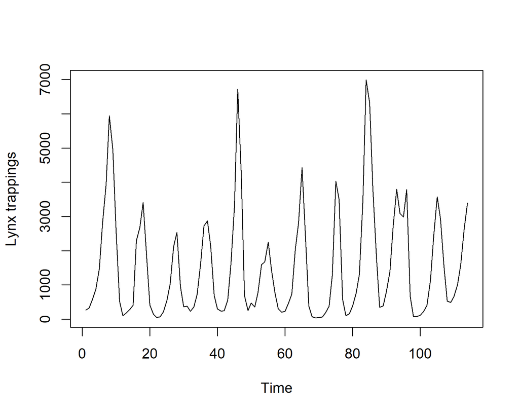

```r
data(lynx)
lynx_full = data.frame(year = 1821:1934,
                       population = as.numeric(lynx),
                       time = 1:NROW(lynx))
plot(lynx_full$population, type = 'l', ylab = 'Lynx trappings',
     xlab = 'Time')
```

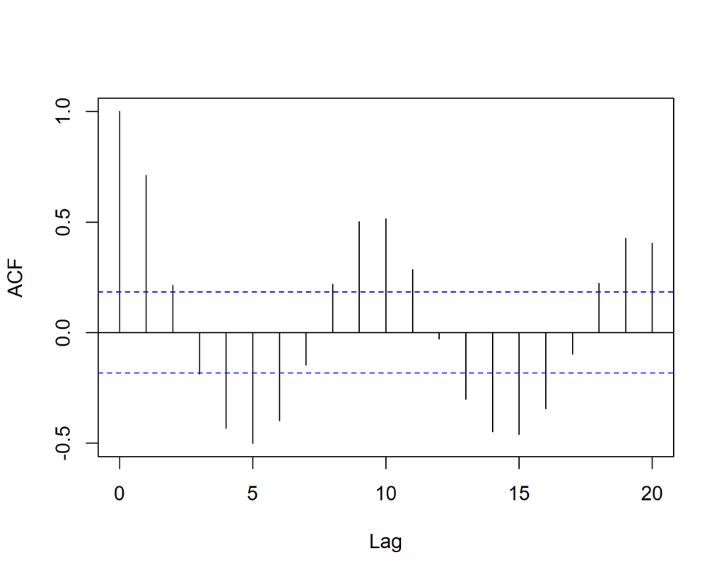

```r
acf(lynx_full$population, main = '')
```

There is a clear ~19-year cyclic pattern to the data, so I create a `season` term that can be used to model this effect and give a better representation of the data generating process. I also create a new `year` term that represents which long-term cycle each observation is in

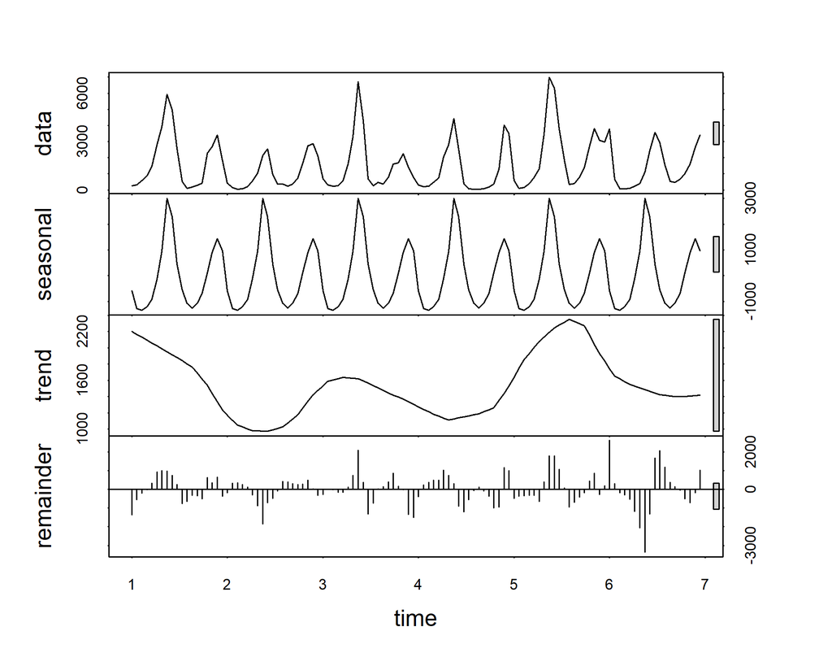

```r
plot(stl(ts(lynx_full$population, frequency = 19), s.window = 'periodic'))
```

```r
lynx_full$season <- (lynx_full$year %%19) + 1
cycle_ends <- c(which(lynx_full$season == 19), NROW(lynx_full))
cycle_starts <- c(1, cycle_ends[1:length(which(lynx_full$season == 19))] + 1)
cycle <- vector(length = NROW(lynx_full))
for(i in 1:length(cycle_starts)){
  cycle[cycle_starts[i]:cycle_ends[i]] <- i
}
lynx_full$year <- cycle
```

Add lag indicators needed to fit the nonlinear lag models that gave the best one step ahead point forecasts in the ESA workshop example. As in the example, we specify the `default` argument in the `lag` function as the mean log population.

```r
mean_pop_l = mean(log(lynx_full$population))
lynx_full = dplyr::mutate(lynx_full,
                   popl = log(population),
                   lag1 = dplyr::lag(popl,1, default = mean_pop_l),
                   lag2 = dplyr::lag(popl,2, default = mean_pop_l),
                   lag3 = dplyr::lag(popl,3, default = mean_pop_l),
                   lag4 = dplyr::lag(popl,4, default = mean_pop_l),
                   lag5 = dplyr::lag(popl,5, default = mean_pop_l),
                   lag6 = dplyr::lag(popl,6, default = mean_pop_l))
```

For `mvgam` models, we need an indicator of the series name as a `factor` variable

```r
lynx_full$series <- factor('series1')
```

Split the data into training (first 40 years) and testing (next 10 years of data) to evaluate multi-step ahead forecasts

```r
lynx_train = lynx_full[1:40, ]
lynx_test = lynx_full[41:50, ]
```

The best-forecasting model in the course was with nonlinear smooths of lags 1 and 2; we use those here is that we also include a cyclic smooth for the 19-year cycles as this seems like an important feature, as well as a yearly smooth for the long-term trend. Following the information about spline extrapolation above, we again fit a cubic `B` spline for the trend with a mix of penalties to try and reign in wacky extrapolation behaviours, and we extend the penalty to cover the years that we wish to predict. This will hopefully give us better uncertainty estimates for the forecast. In this example we assume the observations are Poisson distributed

```r
lynx_mgcv = gam(population ~
                  s(season, bs = 'cc', k = 19) +
                  s(year, bs = 'bs', m = c(3, 2, 1, 0)) +
                  s(lag1, k = 5) +
                  s(lag2, k = 5),
               knots = list(season = c(0.5, 19.5),
                            year = c(min(lynx_train$year - 1),
                                     min(lynx_train$year),
                                     max(lynx_test$year),
                                     max(lynx_test$year) + 1)),
                data = lynx_train, family = "poisson",
                method = "REML")
```

Inspect the model’s summary and estimated smooth functions for the season, year and lag terms

```r
summary(lynx_mgcv)
```

```
##
## Family: poisson
## Link function: log
##
## Formula:
## population ~ s(season, bs = "cc", k = 19) + s(year, bs = "bs",
##     m = c(3, 2, 1, 0)) + s(lag1, k = 5) + s(lag2, k = 5)
##
## Parametric coefficients:
##             Estimate Std. Error z value Pr(>|z|)
## (Intercept) 6.666631   0.007511   887.6   <2e-16 ***
## ---
## Signif. codes:  0 '***' 0.001 '**' 0.01 '*' 0.05 '.' 0.1 ' ' 1
##
## Approximate significance of smooth terms:
##              edf Ref.df Chi.sq p-value
## s(season) 16.229 17.000 6770.2  <2e-16 ***
## s(year)    1.990  2.000  244.2  <2e-16 ***
## s(lag1)    3.984  3.999  712.0  <2e-16 ***
## s(lag2)    3.892  3.993  488.1  <2e-16 ***
## ---
## Signif. codes:  0 '***' 0.001 '**' 0.01 '*' 0.05 '.' 0.1 ' ' 1
##
## R-sq.(adj) =  0.967   Deviance explained = 97.7%
## -REML = 880.28  Scale est. = 1         n = 40
```

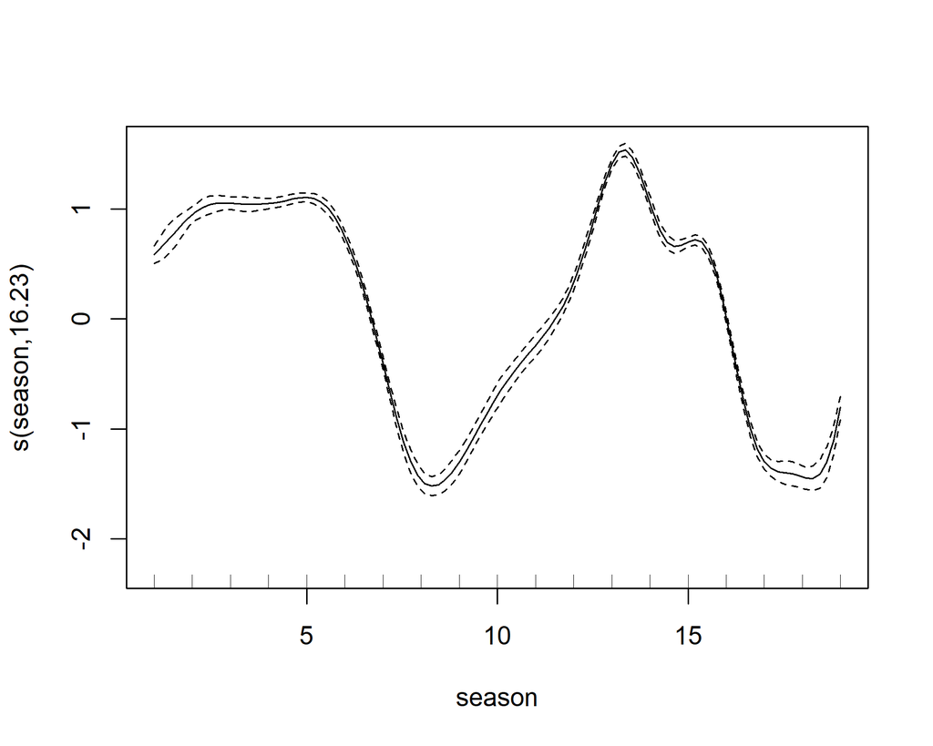

```r
plot(lynx_mgcv, select = 1)
```

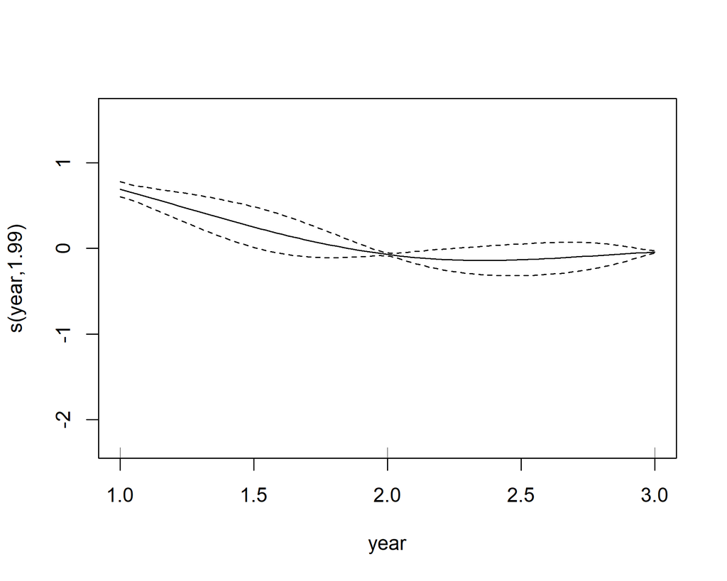

```r
plot(lynx_mgcv, select = 2)
```

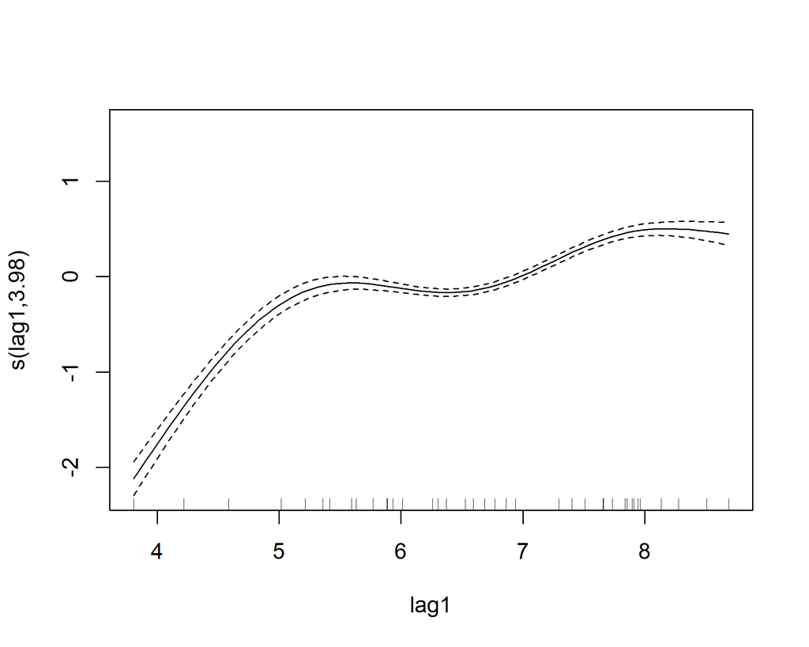

```r
plot(lynx_mgcv, select = 3)
```

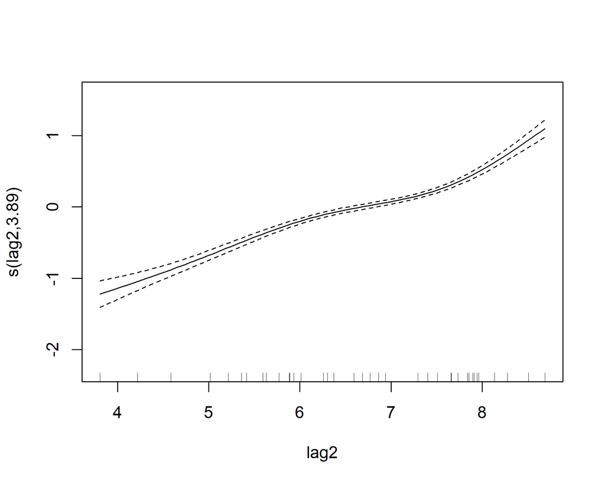

```r
plot(lynx_mgcv, select = 4)
```

This model captures most of the deviance in the series and the functions are all confidently estimated to be non-zero and non-flat. So far, so good. Now for some forecasts for the out of sample period. First we must take posterior draws of smooth beta coefficients to incorporate the uncertainties around smooth functions when simulating forecast paths

```r
coef_sim <- gam.mh(lynx_mgcv)$bs
```

Now we define a function to perform forecast simulations from the nonlinear lag model in a recursive fashion. Using starting values for the last two lags, the function will iteratively project the path ahead with a random sample from the model’s coefficient posterior